# Crime and Incarceration in the United States

# Cultural and political views on crime:

[figure not shown]

[Pew Research Center](https://www.pewresearch.org/fact-tank/2019/10/17/facts-about-crime-in-the-u-s/)

# Overview and problem statement:

With the largest prison population in the world, the U.S. spends $80 Billion annually on corrections expenses.  
The efficacy of these policies is uncertain.

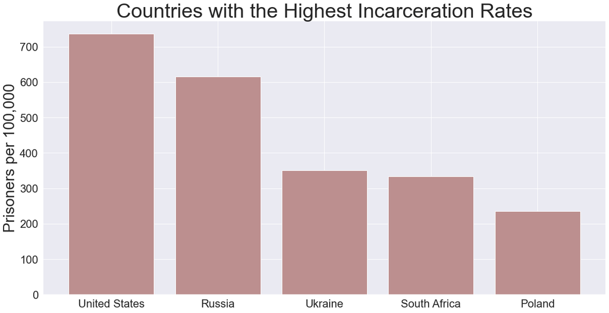

```python
plt.figure(figsize=(20,10))
countries = ['United States', 'Russia', 'Ukraine', 'South Africa', 'Poland']
rates = [737, 615, 350, 334, 235]

sns.set(font_scale=2)
plt.bar(countries, rates, color='rosybrown')
plt.ylabel('Prisoners per 100,000', fontsize=30)
plt.title('Countries with the Highest Incarceration Rates', fontsize=40)

plt.show()
```

# National crime trends:

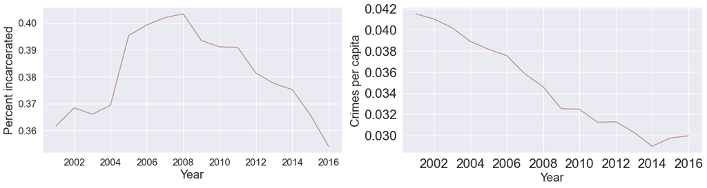

```python
plt.figure(figsize=(20,10))


plt.subplot(222)
sns.set(font_scale=1.5)
plt.plot(all_yrs.groupby('year')['cri_per_cap'].median(), label='crimes per capita', color='rosybrown')
plt.ylabel('Crimes per capita', fontsize=20)
plt.xlabel('Year', fontsize=20)


sns.set(font_scale=1.5)
plt.subplot(221)
plt.plot(all_yrs.groupby('year')['perc_incar'].median(), label='percent incarcerated', color='rosybrown')
plt.ylabel('Percent incarcerated', fontsize=20)
plt.xlabel('Year', fontsize=20)


plt.show()
```

[figure not shown]

[Federal Registrar](https://www.federalregister.gov/documents/2018/04/30/2018-09062/annual-determination-of-average-cost-of-incarceration#:~:text=SUMMARY) [Census.gov](https://www.census.gov/newsroom/press-releases/2020/school-system-finances.html#:~:text=MAY) [BBC News](http://news.bbc.co.uk/2/shared/spl/hi/uk/06/prisons/html/nn2page1.stm)

# Is incarceration an effective means of controlling crime?

### Is the effect on different types of crimes the same?

# Description of the data:

- Crime & incarceration by state from 2001-2016
- Columns added for:  
  - crimes per capita  
  - percent of the population incarcerated
- Excludes jail populations

# Methods:

- Group data by annual change in incarceration rate

> Group A - increased incarceration rate  
> Group B - decreased incarceration rate
- Examine differences in median crime rates between groups
- Group and analyze data by type of crime

# Hypotheses:

*H*<sub>0</sub> : There is no significant difference between the median crime rate for records in Group A and Group B.

*H*<sub>a</sub> : There is a significant difference between the median crime rate for records in Group A and Group B.

# Results:

No significant difference in total crime rates between the two groups

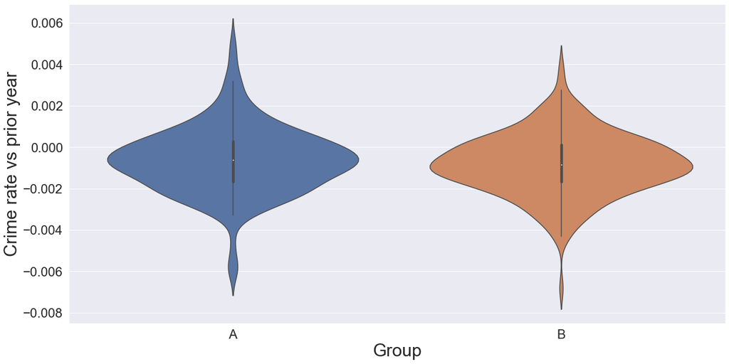

```python
plt.figure(figsize=(20,10))
sns.set(font_scale=2)
ax = sns.violinplot(x='group', y='cr_vs_ly', data=ab_groups)
plt.ylabel('Crime rate vs prior year', fontsize=30)
plt.xlabel('Group', fontsize=30)
#plt.legend('Increased incarceration', 'Decreased incarceration')
plt.show()
# fig = px.violin(all_yrs, y='cr_vs_ly', color='group')

# fig.update_layout({
#     'plot_bgcolor':'rgba(0,0,0,0)'
# })
# fig.show()


# , color_discrete_map({Dark2})


# fig = go.figure

# figg.add_trace(go.Violin(x=all_yrs['cr_vs_ly'][all_yrs['group']=='A'],
#                                y=all_yrs['']))
```

# Violent and property crimes:

Evaluating effect of incarceration on different types of crime

## Violent crime showed a statistically significant difference between groups.

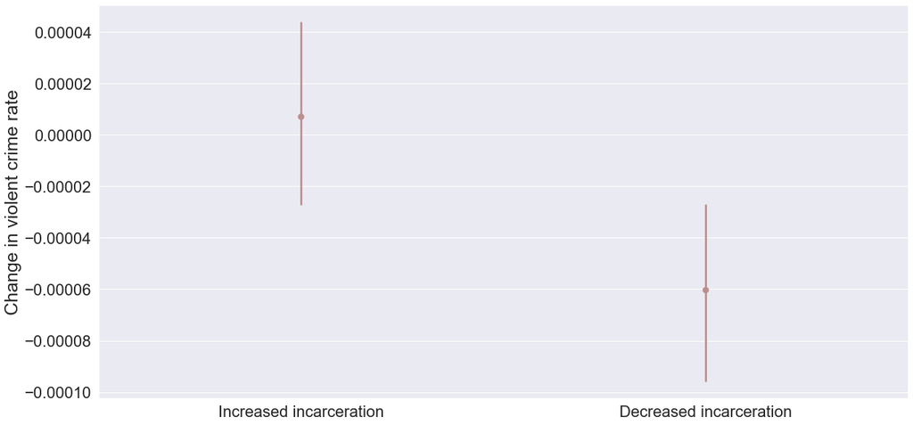

```python
plt.figure(figsize=(20,10))
sns.set(font_scale=2)
g = sns.pointplot(data=[incar_up['viocr_vs_ly'], incar_down['viocr_vs_ly']], join = False, color='rosybrown', fontsize=20)
plt.ylabel('Change in violent crime rate', fontsize=25)
g.set(xticklabels = ['Increased incarceration', 'Decreased incarceration'])
plt.show()


# fig = px.violin(all_yrs, y='viocr_vs_ly', color='group')

# fig.update_layout({
#     'plot_bgcolor':'rgba(0,0,0,0)'
# })
# fig.show()
```

# Discussion:

### Findings:

- Group A did not have a significantly larger decrease in crime rates than Group B
- No significant difference in crime rate change between groups for property crime and total crime

### Limitations & next steps:

- Determining which states are 'tough on crime'
- Difficult to see clear trends over time

# Take aways: